# Operating Characteristics of Multiplier Resampling (MR) — FB / MR (IJ) / MR (field) combined

```
Table: Bias vs coverage, complement block (one-sided = UPPER bound): b = retained bias / empirical SD, r = mean SE / empirical SD (log scale); *_ref = Gaussian bookkeeping prediction at (b, r).

|cell           |estimator |    n|      b|     r|  cov1|  cov2| cov1_ref| cov2_ref|
|:--------------|:---------|----:|------:|-----:|-----:|-----:|--------:|--------:|
|hr=1.50, n=500 |mr        | 1999| -0.276| 1.634| 0.995| 1.000|    0.992|    0.998|
|hr=1.50, n=500 |fld       | 1999| -0.187| 0.849| 0.902| 0.925|    0.887|    0.898|
```

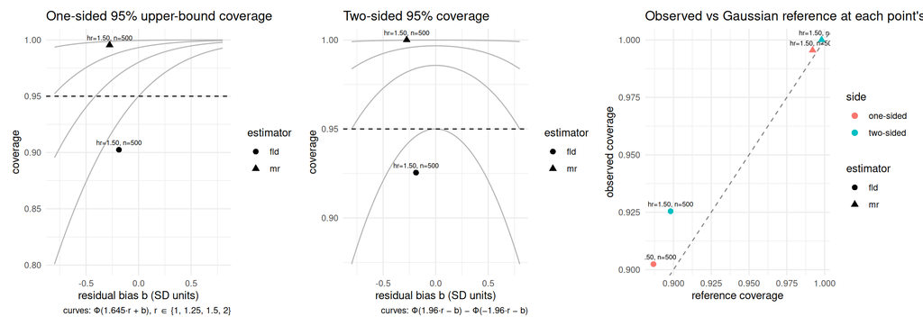

```r
# Complement display (block Hc, side upper): one point per estimator against
# the Gaussian bookkeeping reference Phi(1.645 r + b) for the UPPER bound.
if (run_smoke && !is.null(results) && "fld_Hc_est2" %in% names(results) &&
    any(is.finite(results$fld_Hc_est2))) {
  .ests_Hc <- if (isTRUE(show_winner_rows) && "mr_Hc_se_w" %in% names(results) &&
                  any(is.finite(results$mr_Hc_se_w)))
    c("mr", "mr_w", "mr_wf", "fld") else c("mr", "fld")
  bcc <- fs_sim_bias_coverage(results, block = "Hc", estimators = .ests_Hc,
                              side = "upper")
  bcc$cell <- sprintf("hr=%.2f, n=%d%s", target_hr_harm, n_sample,
                      if (k_random_noise > 0) sprintf(", +%d noise", k_random_noise) else "")
  print(knitr::kable(bcc[, c("cell", "estimator", "n", "b", "r", "cov1", "cov2",
                             "cov1_ref", "cov2_ref")], digits = 3,
    caption = "Bias vs coverage, complement block (one-sided = UPPER bound): b = retained bias / empirical SD, r = mean SE / empirical SD (log scale); *_ref = Gaussian bookkeeping prediction at (b, r)."))
  print(fs_plot_bias_coverage(bcc, side = "upper"))
}
```

```r
# Simultaneous (H lower, Hc upper) pair (TASK_complement_refinements_2026-09-06,
# method B; field_complement = TRUE renders only).  Joint coverage
# beta(Hhat) >= lower_H  AND  beta(Hhat^c) <= upper_Hc for (i) the two separate
# 95% field bounds, (ii) the Bonferroni pair, (iii) the calibrated pair;
# the two margins (log scale) for each; mean gamma, achieved joint probability
# and the draws' correlation.
if (run_smoke && !is.null(results) && "fld_joint_gamma" %in% names(results) &&
    any(is.finite(results$fld_joint_gamma))) {
  rJ <- results[results$detected == 1, , drop = FALSE]
  okj <- is.finite(rJ$betaHhat_H) & is.finite(rJ$betaHhat_Hc) & is.finite(rJ$fld_joint_gamma)
  rJ <- rJ[okj, , drop = FALSE]
  .wl <- function(x, n, z = qnorm(0.975)) {
    ctr <- (x + z^2/(2*n))/(1 + z^2/n); hw <- z*sqrt(x*(1-x)/n + z^2/(4*n^2))/(1 + z^2/n)
    sprintf("%.3f (%.3f, %.3f)", x, ctr - hw, ctr + hw)
  }
  pairs <- list(
    `separate 95% field bounds` = list(lo = rJ$fld_H_lo1s, up = rJ$fld_Hc_up1s),
    `Bonferroni (gamma = 0.025)` = list(lo = rJ$fld_joint_bonf_loH, up = rJ$fld_joint_bonf_upHc),
    `calibrated gamma`           = list(lo = rJ$fld_joint_loH, up = rJ$fld_joint_upHc))
  jt <- do.call(rbind, lapply(names(pairs), function(nm) {
    p <- pairs[[nm]]
    covH  <- rJ$betaHhat_H >= p$lo; covC <- rJ$betaHhat_Hc <= p$up
    data.frame(pair = nm, n = nrow(rJ),
               joint_cov = .wl(mean(covH & covC), nrow(rJ)),
               cov_H = mean(covH), cov_Hc = mean(covC),
               margin_H = mean(log(rJ$mr_H_est) - log(p$lo)),
               margin_Hc = mean(log(p$up) - log(rJ$mr_Hc_est)),
               stringsAsFactors = FALSE)
  }))
  print(knitr::kable(jt, digits = 3,
    caption = sprintf("Joint (Hhat lower, Hhat^c upper) coverage of (beta(Hhat), beta(Hhat^c)) with Wilson intervals; margins on the log scale from the two-term de-biased estimates. Mean gamma = %.4f (achieved joint prob. %.3f; Bonferroni %.3f); mean corr(Lambda*, Lambda*c) = %+.3f; n_joint_draws mean %.0f.",
                      mean(rJ$fld_joint_gamma), mean(rJ$fld_joint_prob), mean(rJ$fld_joint_bonf_prob),
                      mean(rJ$fld_joint_corr), mean(rJ$fld_joint_n))))
}
```

```
Table: Joint (Hhat lower, Hhat^c upper) coverage of (beta(Hhat), beta(Hhat^c)) with Wilson intervals; margins on the log scale from the two-term de-biased estimates. Mean gamma = 0.0251 (achieved joint prob. 0.950; Bonferroni 0.950); mean corr(Lambda*, Lambda*c) = +0.041; n_joint_draws mean 1000.

|pair                       |    n|joint_cov            | cov_H| cov_Hc| margin_H| margin_Hc|
|:--------------------------|----:|:--------------------|-----:|------:|--------:|---------:|
|separate 95% field bounds  | 1999|0.879 (0.864, 0.893) | 0.975|  0.902|    0.629|     0.235|
|Bonferroni (gamma = 0.025) | 1999|0.935 (0.924, 0.945) | 0.989|  0.945|    0.766|     0.278|
|calibrated gamma           | 1999|0.934 (0.923, 0.945) | 0.989|  0.945|    0.766|     0.278|
```

# 16 Identification structure

The supplement’s identification summary (its Figures/Table “FS identification structure”), computed here on this run rather than assembled separately. The engine is `fs_identification_summary()` in the package, so this document, the continuous twin, and the manuscript fragments all share one implementation.

Each detected replicate’s realized rule is classified against the planted triple: the **anchor** `er`, its true binary **partner** `meno`, and the correlated continuous **proxy** `age` that may substitute for the partner. The near-tie between $\{\mathrm{er} \cap \mathrm{meno}\}$ and its `age` proxy is the phenomenon these summaries exist to expose.

```r
# Sweep points are supplied as a NAMED list; a single batch has one point.  The
# manuscript figures pass two or more (n = 500, 1000, ...) and the same call
# draws the trend.  Bundles may be given as in-memory frames (as here) or as
# paths to saved .rds files.
#
# Classification keys on `sg_def`, so this works whether or not `covs` was
# populated -- the GLM/continuous harness leaves `covs` empty by design, and
# reading it directly would classify every replicate as "anchor missed".
id_run <- fs_identification_summary(
  bundles = stats::setNames(list(results), as.character(n_sample)),
  anchor  = "er",     # the factor FS recovers as the trial grows
  partner = "meno",   # the true binary partner
  proxy   = "age",    # correlated continuous covariate FS may substitute
  confounders = confounders_base,
  sweep_label = "Trial size (n)")
id_run
```

```
<fs_identification>
  triple : anchor = er | partner = meno | proxy = age
  sweep  : 500
  500      detection 100.0% of 2000; anchor recovered 64.8%
```

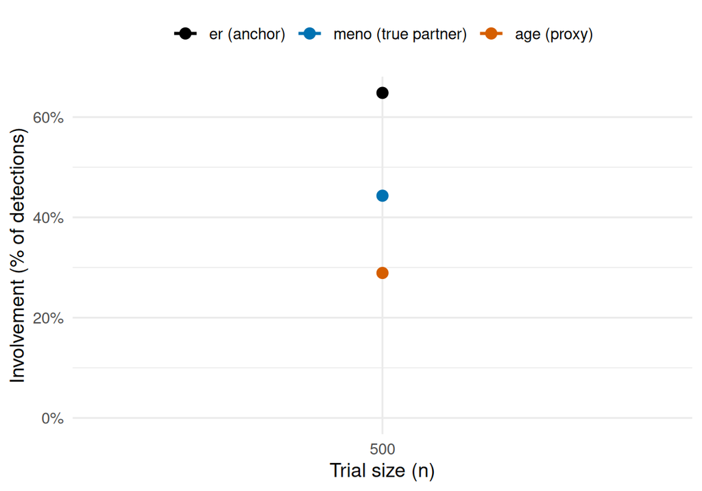

```r
plot_fs_identification_involvement(id_run)
```

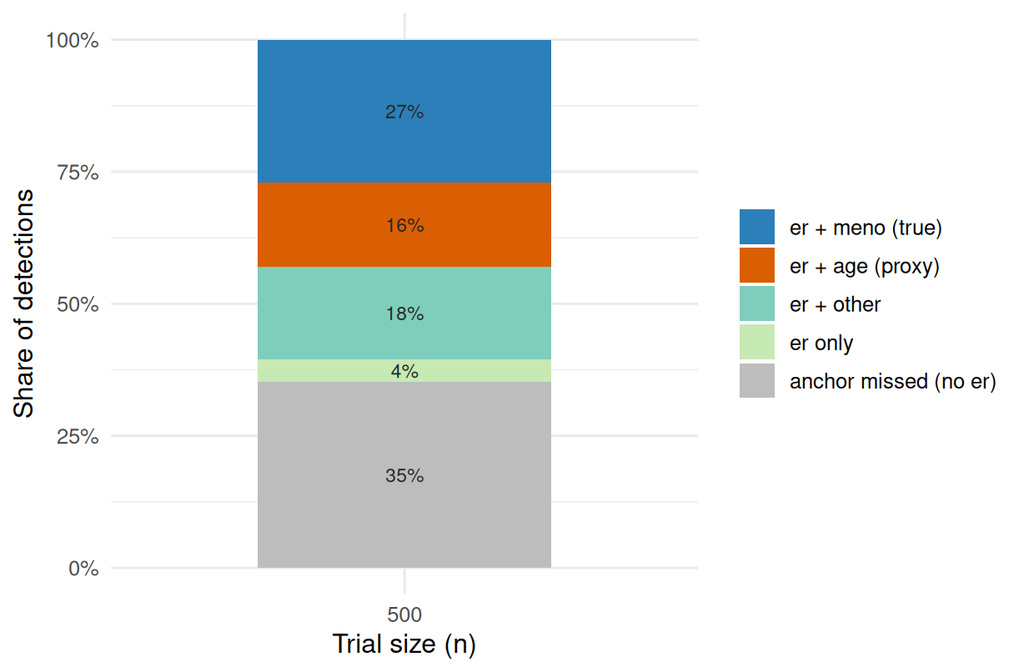

```r
plot_fs_identification_structure(id_run)
```

```r
# as_gt = TRUE renders with gt, matching this document's other tables; the
# manuscript fragment takes the plain data frame instead and styles it with
# kableExtra for LaTeX.  Same numbers either way.
fs_identification_table(id_run, as_gt = TRUE)
```

Identification structure across the sweep

anchor er | true partner meno | proxy age

| Quantity | 500 |
| --- | --- |
| Detection rate (all replicates) | 100.0% |
| er + meno (true partner) | 27.1% |
| er + age (proxy partner) | 15.9% |
| er + other factor | 17.6% |
| er only | 4.3% |
| anchor missed (no er) | 35.2% |
| Anchor recovered (er, any pairing) | 64.8% |
| Conditional partner split, meno : age | 63 : 37 |

Classification of the identified subgroup against the planted membership, averaged over detections (500): sensitivity 0.58, specificity 0.90, PPV 0.71, NPV 0.84.

```r
# PORTED FROM THE CONTINUOUS TWIN: classification accuracy as a TABLE.  The
# estimation-table footnote already carries the means; this adds the medians and
# makes the numbers findable rather than buried in a footnote string.
.rI <- results[results$detected == 1, , drop = FALSE]
if (nrow(.rI)) {
  knitr::kable(data.frame(
    metric = c("sens", "spec", "ppv", "npv"),
    mean   = c(.mfin(.rI$sens), .mfin(.rI$spec), .mfin(.rI$ppv), .mfin(.rI$npv)),
    median = c(.medfin(.rI$sens), .medfin(.rI$spec), .medfin(.rI$ppv), .medfin(.rI$npv))),
    digits = 3,
    caption = "Classification of the identified subgroup vs the true harm flag (detected reps).")
}
```

Classification of the identified subgroup vs the true harm flag (detected reps).

| metric | mean | median |
| --- | --- | --- |
| sens | 0.583 | 0.564 |
| spec | 0.899 | 0.910 |
| ppv | 0.709 | 0.738 |
| npv | 0.836 | 0.826 |